# Predict bankrupt in the subsequent years or not.

Kalpa,Sudha,Arvind

23 July 2017

**NOTE** Clear the environment

```r
rm(list = ls(all=TRUE))
```

## Goal

- Based on various financial ratios , predict whether the company got bankrupt in the subsequent years or not.

## Agenda

- Get the data
- Data Pre-processing
- Build a model
- Predictions
- Communication

### Libraries used

```r
library(ROSE)
```

```r
library(corrplot)
library(caret)
library(C50)
library(rpart)
library(rpart.plot)
library(DMwR)
library(class)
library(mice)
library(vegan)
library(randomForest)
library(inTrees)
library(e1071)
```

## Reading & Understanding the Data

### Read the Data

```r
setwd("C:/insofe\\cute3")
bank_data <- read.csv("bankdata.csv")
```

### Understand the data

- Using the str(), summary(), head() and tail() functions to get the dimensions and types of attributes in the dataset
- The dataset has 43004 observations and 65 variables

```r
str(bank_data)
```

```
## 'data.frame':    43004 obs. of  65 variables:
##  $ Attr1 : num  0.2006 0.2091 0.2487 0.0815 0.1873 ...
##  $ Attr2 : num  0.38 0.5 0.696 0.307 0.613 ...
##  $ Attr3 : num  0.396 0.472 0.267 0.459 0.23 ...
##  $ Attr4 : num  2.05 1.94 1.55 2.49 1.41 ...
##  $ Attr5 : num  32.35 14.79 -1.15 51.95 -7.31 ...
##  $ Attr6 : num  0.388 0 0 0.15 0.187 ...
##  $ Attr7 : num  0.2498 0.2583 0.3091 0.0927 0.1873 ...
##  $ Attr8 : num  1.331 0.996 0.437 1.866 0.631 ...
##  $ Attr9 : num  1.14 1.7 1.31 1.06 1.16 ...
##  $ Attr10: num  0.505 0.498 0.304 0.574 0.387 ...
##  $ Attr11: num  0.2498 0.2611 0.3126 0.0927 0.1873 ...
##  $ Attr12: num  0.66 0.517 0.642 0.302 0.331 ...
##  $ Attr13: num  0.1666 0.1583 0.2444 0.0943 0.1218 ...
##  $ Attr14: num  0.2498 0.2583 0.3091 0.0927 0.1873 ...
```

[output cut: 51 more lines]

```r
summary(bank_data)
```

```
##      Attr1               Attr2               Attr3
##  Min.   :-463.8900   Min.   :-430.8700   Min.   :-479.9600
##  1st Qu.:   0.0034   1st Qu.:   0.2699   1st Qu.:   0.0215
##  Median :   0.0497   Median :   0.4724   Median :   0.1968
##  Mean   :   0.0408   Mean   :   0.5919   Mean   :   0.1137
##  3rd Qu.:   0.1297   3rd Qu.:   0.6891   3rd Qu.:   0.4036
##  Max.   :  94.2800   Max.   : 480.9600   Max.   :  28.3360
##  NA's   :8           NA's   :8           NA's   :8
##      Attr4              Attr5               Attr6
##  Min.   :   -0.40   Min.   :-11903000   Min.   :-508.4100
##  1st Qu.:    1.05   1st Qu.:      -49   1st Qu.:   0.0000
##  Median :    1.57   Median :       -1   Median :   0.0000
##  Mean   :    6.34   Mean   :     -386   Mean   :  -0.0576
##  3rd Qu.:    2.79   3rd Qu.:       51   3rd Qu.:   0.0877
##  Max.   :53433.00   Max.   :  1250100   Max.   : 543.2500
##  NA's   :133        NA's   :89          NA's   :8
##      Attr7               Attr8              Attr9
##  Min.   :-517.4800   Min.   : -141.41   Min.   :  -3.496
##  1st Qu.:   0.0057   1st Qu.:    0.43   1st Qu.:   1.019
##  Median :   0.0596   Median :    1.07   Median :   1.199
##  Mean   :   0.0979   Mean   :   12.03   Mean   :   2.575
##  3rd Qu.:   0.1511   3rd Qu.:    2.60   3rd Qu.:   2.070
##  Max.   : 649.2300   Max.   :53432.00   Max.   :9742.300
##  NA's   :8           NA's   :93         NA's   :9
##      Attr10              Attr11              Attr12
##  Min.   :-479.9100   Min.   :-463.8900   Min.   :-6331.800
##  1st Qu.:   0.2946   1st Qu.:   0.0154   1st Qu.:    0.015
##  Median :   0.5053   Median :   0.0754   Median :    0.172
##  Mean   :   0.6049   Mean   :   0.1358   Mean   :    1.128
##  3rd Qu.:   0.7081   3rd Qu.:   0.1670   3rd Qu.:    0.586
##  Max.   :1099.5000   Max.   : 681.5400   Max.   : 8259.400
##  NA's   :8           NA's   :44          NA's   :133
##      Attr13              Attr14              Attr15
##  Min.   :-1460.600   Min.   :-517.4800   Min.   :-9632400
##  1st Qu.:    0.024   1st Qu.:   0.0058   1st Qu.:     222
##  Median :    0.068   Median :   0.0596   Median :     846
##  Mean   :    0.812   Mean   :   0.0980   Mean   :    1998
##  3rd Qu.:    0.135   3rd Qu.:   0.1511   3rd Qu.:    2229
##  Max.   :13315.000   Max.   : 649.2300   Max.   :10236000
##  NA's   :125         NA's   :8           NA's   :36
```

[output cut: 121 more lines]

```
##  Min.   :   -12.66   Min.   :-2336500   Min.   :   -1.543
##  1st Qu.:     4.52   1st Qu.:      42   1st Qu.:    3.099
##  Median :     6.65   Median :      71   Median :    5.091
##  Mean   :    17.11   Mean   :    1509   Mean   :    9.368
##  3rd Qu.:    10.43   3rd Qu.:     117   3rd Qu.:    8.612
##  Max.   :108000.00   Max.   :25016000   Max.   :23454.000
##  NA's   :101         NA's   :125        NA's   :133
##      Attr64          target
##  Min.   :-10677.00   No :40921
##  1st Qu.:     2.18   Yes: 2083
##  Median :     4.31
##  Mean   :    72.65
##  3rd Qu.:     9.83
##  Max.   :294770.00
##  NA's   :804
```

```r
head(bank_data)
```

```
##      Attr1   Attr2   Attr3  Attr4    Attr5   Attr6    Attr7   Attr8  Attr9
## 1 0.200550 0.37951 0.39641 2.0472  32.3510 0.38825 0.249760 1.33050 1.1389
## 2 0.209120 0.49988 0.47225 1.9447  14.7860 0.00000 0.258340 0.99601 1.6996
## 3 0.248660 0.69592 0.26713 1.5548  -1.1523 0.00000 0.309060 0.43695 1.3090
## 4 0.081483 0.30734 0.45879 2.4928  51.9520 0.14988 0.092704 1.86610 1.0571
## 5 0.187320 0.61323 0.22960 1.4063  -7.3128 0.18732 0.187320 0.63070 1.1559
## 6 0.228220 0.49794 0.35969 1.7502 -47.7170 0.00000 0.281390 1.00830 1.9786
##    Attr10   Attr11  Attr12   Attr13   Attr14  Attr15  Attr16 Attr17
## 1 0.50494 0.249760 0.65980 0.166600 0.249760  497.42 0.73378 2.6349
## 2 0.49788 0.261140 0.51680 0.158350 0.258340  677.96 0.53838 2.0005
## 3 0.30408 0.312580 0.64184 0.244350 0.309060  794.16 0.45961 1.4369
## 4 0.57353 0.092704 0.30163 0.094257 0.092704  917.01 0.39803 3.2537
## 5 0.38677 0.187320 0.33147 0.121820 0.187320 1133.20 0.32211 1.6307
## 6 0.50206 0.286450 0.58691 0.148120 0.281390  620.14 0.58858 2.0083
##     Attr18   Attr19  Attr20 Attr21  Attr22   Attr23  Attr24  Attr25
```

[output cut: 41 more lines]

```r
tail(bank_data)
```

```
##           Attr1   Attr2     Attr3   Attr4    Attr5    Attr6     Attr7
## 42999 -0.283380 0.97794 -0.125140 0.64902  -56.126 -1.32980 -0.283380
## 43000  0.012898 0.70621  0.038857 1.17220  -18.907  0.00000  0.013981
## 43001 -0.578050 0.96702 -0.800850 0.16576  -67.365 -0.57805 -0.578050
## 43002 -0.179050 1.25530 -0.275990 0.74554 -120.440 -0.17905 -0.154930
## 43003 -0.108860 0.74394  0.015449 1.08780  -17.003 -0.10886 -0.109180
## 43004 -0.105370 0.53629 -0.045578 0.91478  -56.068 -0.10537 -0.109940
##           Attr8   Attr9    Attr10    Attr11    Attr12    Attr13    Attr14
## 42999  0.022514 1.39430  0.022018 -0.283380 -0.794780 -0.203240 -0.283380
## 43000  0.416000 1.67680  0.293790  0.041583  0.061959  0.023622  0.013981
## 43001 -0.403340 0.93979 -0.390040 -0.578050 -0.602160 -0.110220 -0.578050
## 43002 -0.260180 1.17490 -0.326590 -0.154930 -0.142840 -0.072940 -0.154930
## 43003  0.125310 0.84516  0.093224 -0.109180 -0.620380 -0.065652 -0.109180
## 43004  0.864600 0.95040  0.463670 -0.109940 -0.205570 -0.066747 -0.109940
##         Attr15    Attr16  Attr17    Attr18    Attr19  Attr20  Attr21
```

[output cut: 48 more lines]

### Data Description

Attr1 net profit / total assets Attr2 total liabilities / total assets Attr3 working capital / total assets Attr4 current assets / short-term liabilities Attr5 [(cash + short-term securities + receivables - short-term liabilities) / (operating expenses - depreciation)] * 365 Attr6 retained earnings / total assets Attr7 EBIT / total assets Attr8 book value of equity / total liabilities Attr9 sales / total assets Attr10 equity / total assets Attr11 (gross profit + extraordinary items + financial expenses) / total assets Attr12 gross profit / short-term liabilities Attr13 (gross profit + depreciation) / sales Attr14 (gross profit + interest) / total assets Attr15 (total liabilities * 365) / (gross profit + depreciation) Attr16 (gross profit + depreciation) / total liabilities Attr17 total assets / total liabilities Attr18 gross profit / total assets Attr19 gross profit / sales Attr20 (inventory * 365) / sales Attr21 sales (n) / sales (n-1) Attr22 profit on operating activities / total assets Attr23 net profit / sales Attr24 gross profit (in 3 years) / total assets Attr25 (equity - share capital) / total assets Attr26 (net profit + depreciation) / total liabilities Attr27 profit on operating activities / financial expenses Attr28 working capital / fixed assets Attr29 logarithm of total assets Attr30 (total liabilities - cash) / sales Attr31 (gross profit + interest) / sales Attr32 (current liabilities * 365) / cost of products sold Attr33 operating expenses / short-term liabilities Attr34 operating expenses / total liabilities Attr35 profit on sales / total assets Attr36 total sales / total assets Attr37 (current assets - inventories) / long-term liabilities Attr38 constant capital / total assets Attr39 profit on sales / sales Attr40 (current assets - inventory - receivables) / short-term liabilities Attr41 total liabilities / ((profit on operating activities + depreciation) * (12/365)) Attr42 profit on operating activities / sales Attr43 rotation receivables + inventory turnover in days Attr44 (receivables * 365) / sales Attr45 net profit / inventory Attr46 (current assets - inventory) / short-term liabilities Attr47 (inventory * 365) / cost of products sold Attr48 EBITDA (profit on operating activities - depreciation) / total assets Attr49 EBITDA (profit on operating activities - depreciation) / sales Attr50 current assets / total liabilities Attr51 short-term liabilities / total assets Attr52 (short-term liabilities * 365) / cost of products sold) Attr53 equity / fixed assets Attr54 constant capital / fixed assets Attr55 working capital Attr56 (sales - cost of products sold) / sales Attr57 (current assets - inventory - short-term liabilities) / (sales - gross profit - depreciation) Attr58 total costs /total sales Attr59 long-term liabilities / equity Attr60 sales / inventory Attr61 sales / receivables Attr62 (short-term liabilities *365) / sales Attr63 sales / short-term liabilities Attr64 sales / fixed assets

## Data Pre-processing

### Verify Data Integrity

```r
summary(bank_data)
```

```
##      Attr1               Attr2               Attr3
##  Min.   :-463.8900   Min.   :-430.8700   Min.   :-479.9600
##  1st Qu.:   0.0034   1st Qu.:   0.2699   1st Qu.:   0.0215
##  Median :   0.0497   Median :   0.4724   Median :   0.1968
##  Mean   :   0.0408   Mean   :   0.5919   Mean   :   0.1137
##  3rd Qu.:   0.1297   3rd Qu.:   0.6891   3rd Qu.:   0.4036
##  Max.   :  94.2800   Max.   : 480.9600   Max.   :  28.3360
##  NA's   :8           NA's   :8           NA's   :8
##      Attr4              Attr5               Attr6
##  Min.   :   -0.40   Min.   :-11903000   Min.   :-508.4100
##  1st Qu.:    1.05   1st Qu.:      -49   1st Qu.:   0.0000
##  Median :    1.57   Median :       -1   Median :   0.0000
##  Mean   :    6.34   Mean   :     -386   Mean   :  -0.0576
##  3rd Qu.:    2.79   3rd Qu.:       51   3rd Qu.:   0.0877
##  Max.   :53433.00   Max.   :  1250100   Max.   : 543.2500
##  NA's   :133        NA's   :89          NA's   :8
##      Attr7               Attr8              Attr9
##  Min.   :-517.4800   Min.   : -141.41   Min.   :  -3.496
##  1st Qu.:   0.0057   1st Qu.:    0.43   1st Qu.:   1.019
##  Median :   0.0596   Median :    1.07   Median :   1.199
##  Mean   :   0.0979   Mean   :   12.03   Mean   :   2.575
##  3rd Qu.:   0.1511   3rd Qu.:    2.60   3rd Qu.:   2.070
##  Max.   : 649.2300   Max.   :53432.00   Max.   :9742.300
##  NA's   :8           NA's   :93         NA's   :9
##      Attr10              Attr11              Attr12
##  Min.   :-479.9100   Min.   :-463.8900   Min.   :-6331.800
##  1st Qu.:   0.2946   1st Qu.:   0.0154   1st Qu.:    0.015
##  Median :   0.5053   Median :   0.0754   Median :    0.172
##  Mean   :   0.6049   Mean   :   0.1358   Mean   :    1.128
##  3rd Qu.:   0.7081   3rd Qu.:   0.1670   3rd Qu.:    0.586
##  Max.   :1099.5000   Max.   : 681.5400   Max.   : 8259.400
##  NA's   :8           NA's   :44          NA's   :133
##      Attr13              Attr14              Attr15
##  Min.   :-1460.600   Min.   :-517.4800   Min.   :-9632400
##  1st Qu.:    0.024   1st Qu.:   0.0058   1st Qu.:     222
##  Median :    0.068   Median :   0.0596   Median :     846
##  Mean   :    0.812   Mean   :   0.0980   Mean   :    1998
##  3rd Qu.:    0.135   3rd Qu.:   0.1511   3rd Qu.:    2229
##  Max.   :13315.000   Max.   : 649.2300   Max.   :10236000
##  NA's   :125         NA's   :8           NA's   :36
```

[output cut: 121 more lines]

```
##  Min.   :   -12.66   Min.   :-2336500   Min.   :   -1.543
##  1st Qu.:     4.52   1st Qu.:      42   1st Qu.:    3.099
##  Median :     6.65   Median :      71   Median :    5.091
##  Mean   :    17.11   Mean   :    1509   Mean   :    9.368
##  3rd Qu.:    10.43   3rd Qu.:     117   3rd Qu.:    8.612
##  Max.   :108000.00   Max.   :25016000   Max.   :23454.000
##  NA's   :101         NA's   :125        NA's   :133
##      Attr64          target
##  Min.   :-10677.00   No :40921
##  1st Qu.:     2.18   Yes: 2083
##  Median :     4.31
##  Mean   :    72.65
##  3rd Qu.:     9.83
##  Max.   :294770.00
##  NA's   :804
```

```r
head(bank_data)
```

```
##      Attr1   Attr2   Attr3  Attr4    Attr5   Attr6    Attr7   Attr8  Attr9
## 1 0.200550 0.37951 0.39641 2.0472  32.3510 0.38825 0.249760 1.33050 1.1389
## 2 0.209120 0.49988 0.47225 1.9447  14.7860 0.00000 0.258340 0.99601 1.6996
## 3 0.248660 0.69592 0.26713 1.5548  -1.1523 0.00000 0.309060 0.43695 1.3090
## 4 0.081483 0.30734 0.45879 2.4928  51.9520 0.14988 0.092704 1.86610 1.0571
## 5 0.187320 0.61323 0.22960 1.4063  -7.3128 0.18732 0.187320 0.63070 1.1559
## 6 0.228220 0.49794 0.35969 1.7502 -47.7170 0.00000 0.281390 1.00830 1.9786
##    Attr10   Attr11  Attr12   Attr13   Attr14  Attr15  Attr16 Attr17
## 1 0.50494 0.249760 0.65980 0.166600 0.249760  497.42 0.73378 2.6349
## 2 0.49788 0.261140 0.51680 0.158350 0.258340  677.96 0.53838 2.0005
## 3 0.30408 0.312580 0.64184 0.244350 0.309060  794.16 0.45961 1.4369
## 4 0.57353 0.092704 0.30163 0.094257 0.092704  917.01 0.39803 3.2537
## 5 0.38677 0.187320 0.33147 0.121820 0.187320 1133.20 0.32211 1.6307
## 6 0.50206 0.286450 0.58691 0.148120 0.281390  620.14 0.58858 2.0083
##     Attr18   Attr19  Attr20 Attr21  Attr22   Attr23  Attr24  Attr25
```

[output cut: 41 more lines]

```r
tail(bank_data)
```

```
##           Attr1   Attr2     Attr3   Attr4    Attr5    Attr6     Attr7
## 42999 -0.283380 0.97794 -0.125140 0.64902  -56.126 -1.32980 -0.283380
## 43000  0.012898 0.70621  0.038857 1.17220  -18.907  0.00000  0.013981
## 43001 -0.578050 0.96702 -0.800850 0.16576  -67.365 -0.57805 -0.578050
## 43002 -0.179050 1.25530 -0.275990 0.74554 -120.440 -0.17905 -0.154930
## 43003 -0.108860 0.74394  0.015449 1.08780  -17.003 -0.10886 -0.109180
## 43004 -0.105370 0.53629 -0.045578 0.91478  -56.068 -0.10537 -0.109940
##           Attr8   Attr9    Attr10    Attr11    Attr12    Attr13    Attr14
## 42999  0.022514 1.39430  0.022018 -0.283380 -0.794780 -0.203240 -0.283380
## 43000  0.416000 1.67680  0.293790  0.041583  0.061959  0.023622  0.013981
## 43001 -0.403340 0.93979 -0.390040 -0.578050 -0.602160 -0.110220 -0.578050
## 43002 -0.260180 1.17490 -0.326590 -0.154930 -0.142840 -0.072940 -0.154930
## 43003  0.125310 0.84516  0.093224 -0.109180 -0.620380 -0.065652 -0.109180
## 43004  0.864600 0.95040  0.463670 -0.109940 -0.205570 -0.066747 -0.109940
##         Attr15    Attr16  Attr17    Attr18    Attr19  Attr20  Attr21
```

[output cut: 48 more lines]

# Verify the data types assigned to the variables in the dataset

```r
str(bank_data)
```

```
## 'data.frame':    43004 obs. of  65 variables:
##  $ Attr1 : num  0.2006 0.2091 0.2487 0.0815 0.1873 ...
##  $ Attr2 : num  0.38 0.5 0.696 0.307 0.613 ...
##  $ Attr3 : num  0.396 0.472 0.267 0.459 0.23 ...
##  $ Attr4 : num  2.05 1.94 1.55 2.49 1.41 ...
##  $ Attr5 : num  32.35 14.79 -1.15 51.95 -7.31 ...
##  $ Attr6 : num  0.388 0 0 0.15 0.187 ...
##  $ Attr7 : num  0.2498 0.2583 0.3091 0.0927 0.1873 ...
##  $ Attr8 : num  1.331 0.996 0.437 1.866 0.631 ...
##  $ Attr9 : num  1.14 1.7 1.31 1.06 1.16 ...
##  $ Attr10: num  0.505 0.498 0.304 0.574 0.387 ...
##  $ Attr11: num  0.2498 0.2611 0.3126 0.0927 0.1873 ...
##  $ Attr12: num  0.66 0.517 0.642 0.302 0.331 ...
##  $ Attr13: num  0.1666 0.1583 0.2444 0.0943 0.1218 ...
##  $ Attr14: num  0.2498 0.2583 0.3091 0.0927 0.1873 ...
```

[output cut: 51 more lines]

# Plot the data to understand

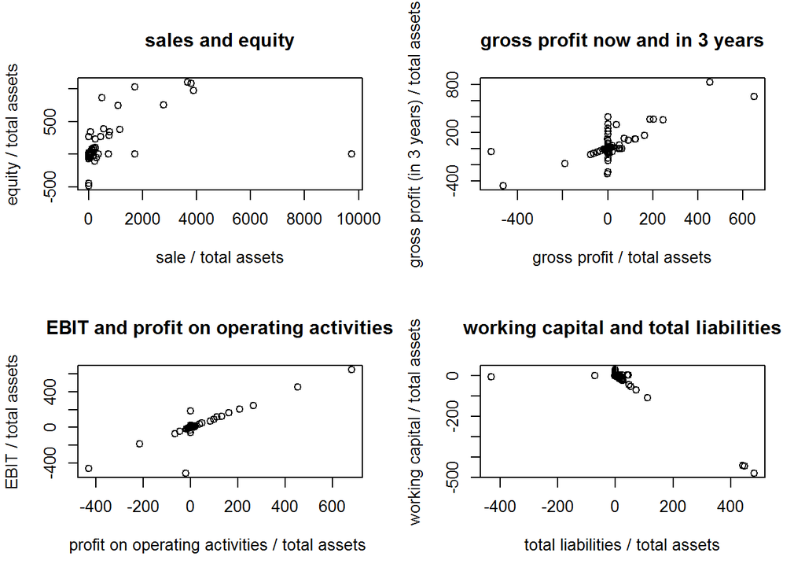

```r
par(mfrow = c(2,2))

plot(bank_data[,"Attr9"],bank_data[,"Attr10"],xlab="sale / total assets",ylab="equity / total assets",type="p",main="sales and equity" )
plot(bank_data[,"Attr18"],bank_data[,"Attr24"],xlab="gross profit / total assets",ylab="gross profit (in 3 years) / total assets",type="p",main="gross profit now and in 3 years" )
plot(bank_data[,"Attr22"],bank_data[,"Attr7"],xlab="profit on operating activities / total assets ",ylab="EBIT / total assets",type="p",main="EBIT and profit on operating activities" )
plot(bank_data[,"Attr2"],bank_data[,"Attr3"],xlab="total liabilities / total assets",ylab="working capital / total assets",type="p",main="working capital and total liabilities" )
```

# Substracting current gross income from gross income in 3 years

```r
str(bank_data)
```

```
## 'data.frame':    43004 obs. of  65 variables:
##  $ Attr1 : num  0.2006 0.2091 0.2487 0.0815 0.1873 ...
##  $ Attr2 : num  0.38 0.5 0.696 0.307 0.613 ...
##  $ Attr3 : num  0.396 0.472 0.267 0.459 0.23 ...
##  $ Attr4 : num  2.05 1.94 1.55 2.49 1.41 ...
##  $ Attr5 : num  32.35 14.79 -1.15 51.95 -7.31 ...
##  $ Attr6 : num  0.388 0 0 0.15 0.187 ...
##  $ Attr7 : num  0.2498 0.2583 0.3091 0.0927 0.1873 ...
##  $ Attr8 : num  1.331 0.996 0.437 1.866 0.631 ...
##  $ Attr9 : num  1.14 1.7 1.31 1.06 1.16 ...
##  $ Attr10: num  0.505 0.498 0.304 0.574 0.387 ...
##  $ Attr11: num  0.2498 0.2611 0.3126 0.0927 0.1873 ...
##  $ Attr12: num  0.66 0.517 0.642 0.302 0.331 ...
##  $ Attr13: num  0.1666 0.1583 0.2444 0.0943 0.1218 ...
##  $ Attr14: num  0.2498 0.2583 0.3091 0.0927 0.1873 ...
```

[output cut: 51 more lines]

```r
bank_data1= cbind(bank_data,data.frame(bank_data$Attr24-bank_data$Attr18))
```

# Check for missing values

```r
sum(is.na(bank_data))
```

```
## [1] 41037
```

```r
bank_data=centralImputation(bank_data)
sum(is.na(bank_data))
```

```
## [1] 0
```

### Check for class imbalance

```r
prop.table(table(bank_data$target))
```

```
##
##         No        Yes
## 0.95156265 0.04843735
```

```r
bank_data_rose <- ROSE(target~ ., data=bank_data, seed=111)$data
prop.table(table(bank_data_rose$target))
```

```
##
##        No       Yes
## 0.5009767 0.4990233
```

# Find the corelation between the features.

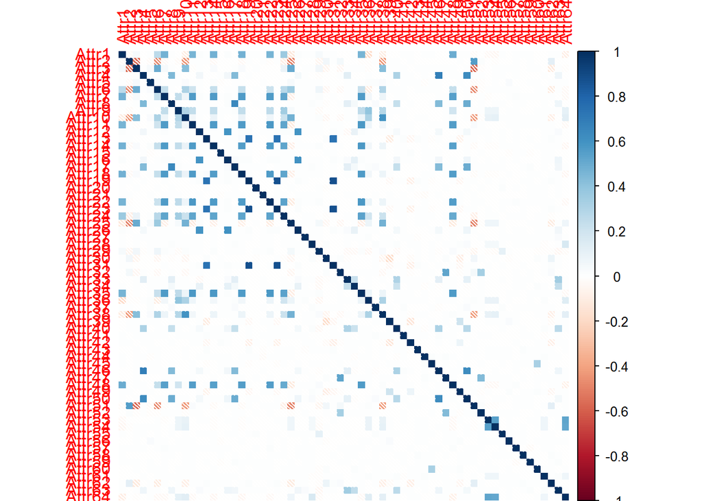

```r
cat_var="target"
num_var=setdiff(names(bank_data),cat_var)
corrplot(cor(bank_data_rose[,num_var]), method="shade",type = "full")
```

# Split the Data into train and test sets

- Use stratified sampling to split the data into train/test sets (70/30)
- Use the createDataPartition() function from the caret package to do stratified sampling

```r
# Set the seed after attaching the caret package

set.seed(111)

# The first argument is the imbalanced class reference variable, the second is the proportion to sample

# Remember to include list = F as the function returns a list otherwise which would not be able to subset a dataframe

trainIndex <- createDataPartition(bank_data$target, p = .7, list = F)

train_data <- bank_data[trainIndex, ]

test_data <- bank_data[-trainIndex, ]
```

## Build a Decision Tree

### Model the tree

- We will be using Quinlan’s C5.0 decision tree algorithm implementation from the C50 package to build our decision tree

```r
c5_tree <- C5.0(target ~ . , train_data)

# Use the rules = T argument if you want to extract rules later from the model

c5_rules <- C5.0(target ~ . , train_data, rules = T)
```

### Variable Importance in trees

- Find the importance of each variable in the dataset using the c5imp() function
- The default metric “usage” in the c5imp function gives the percentage of data being split by using the attribute at that particular time. So variable used for splitting at the root node always has 100, and the variables at the leaf nodes might be close to 0 if there is no data remaining to classify

```r
C5imp(c5_tree, metric = "usage")
```

```
##        Overall
## Attr41  100.00
## Attr27   98.78
## Attr46   95.17
## Attr24   72.55
## Attr39   65.61
## Attr34   44.82
## Attr6    35.79
## Attr26   33.33
## Attr58   29.38
## Attr61   23.64
## Attr5    21.06
## Attr30   15.11
## Attr28   14.44
## Attr20   11.45
## Attr56    7.64
## Attr4     7.54
## Attr15    6.47
## Attr55    3.04
## Attr51    2.53
## Attr44    2.18
## Attr47    1.68
## Attr25    0.86
## Attr36    0.78
## Attr50    0.77
## Attr35    0.76
## Attr13    0.62
## Attr63    0.42
## Attr49    0.36
## Attr12    0.29
## Attr22    0.23
## Attr40    0.23
## Attr32    0.22
## Attr19    0.19
## Attr21    0.18
## Attr1     0.16
## Attr7     0.13
## Attr53    0.10
## Attr42    0.09
## Attr17    0.09
```

[output cut: 10 more lines]

```
## Attr14    0.00
## Attr16    0.00
## Attr18    0.00
## Attr23    0.00
## Attr29    0.00
## Attr38    0.00
## Attr43    0.00
## Attr45    0.00
## Attr48    0.00
## Attr52    0.00
## Attr54    0.00
## Attr57    0.00
## Attr59    0.00
## Attr60    0.00
## Attr64    0.00
```

### Rules from trees

- Understand the summary of the returned c5.0 rules based on the decision tree model

```r
summary(c5_rules)
```

```
##
## Call:
## C5.0.formula(formula = target ~ ., data = train_data, rules = T)
##
##
## C5.0 [Release 2.07 GPL Edition]      Fri Sep 01 12:47:20 2017
## -------------------------------
##
## Class specified by attribute `outcome'
##
## Read 30104 cases (65 attributes) from undefined.data
##
## Rules:
##
## Rule 1: (1588, lift 1.1)
##  Attr27 <= -0.011324
##  Attr34 <= 0.002203
##  ->  class No  [0.999]
##
## Rule 2: (1097/15, lift 1.0)
##  Attr5 > 218.31
##  Attr58 <= 0.94767
##  ->  class No  [0.985]
##
## Rule 3: (296/4, lift 1.0)
##  Attr12 > 0.022446
##  Attr27 <= -0.011324
##  ->  class No  [0.983]
##
## Rule 4: (14226/343, lift 1.0)
##  Attr35 > -0.011678
##  Attr58 <= 0.94767
##  ->  class No  [0.976]
##
## Rule 5: (14062/438, lift 1.0)
##  Attr27 > 1.092
##  ->  class No  [0.969]
##
## Rule 6: (15531/1005, lift 1.0)
##  Attr58 > 0.94767
```

[output cut: 262 more lines]

```
##    0.11% Attr17
##    0.11% Attr55
##    0.10% Attr7
##    0.08% Attr11
##    0.05% Attr40
##    0.04% Attr37
##    0.04% Attr1
##    0.04% Attr21
##    0.04% Attr47
##    0.04% Attr20
##    0.04% Attr36
##    0.02% Attr13
##
##
## Time: 10.3 secs
```

- From the output of the summary above, you can clearly understand the rules and their associated metrics such as lift and support
- **This is great for explicability and can also be used for understanding interesting relationships in data, even if your final model is not a decision tree**

### Plotting the tree

- Call the plot function on the tree object to visualize the tree

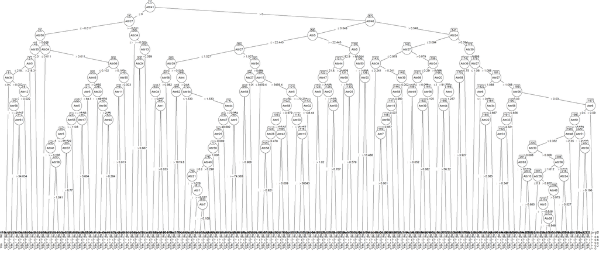

```r
plot(c5_tree)
```

## Evaluating the model

### Predictions on the test data

- We’ll evaluate the decision tree using the standard error metrics on test data

```r
preds <- predict(c5_tree, train_data)
preds1 <- predict(c5_tree, test_data)
```

- Error metrics for classification can be accessed through the “confusionMatrix()” function from the caret package

```r
conf_train=confusionMatrix(preds, train_data$target, positive = "No")
conf_test=confusionMatrix(preds1, test_data$target, positive = "No")
conf_train
```

```
## Confusion Matrix and Statistics
##
##           Reference
## Prediction    No   Yes
##        No  28616   660
##        Yes    29   799
##
##                Accuracy : 0.9771
##                  95% CI : (0.9754, 0.9788)
##     No Information Rate : 0.9515
##     P-Value [Acc > NIR] : < 2.2e-16
##
##                   Kappa : 0.6878
##  Mcnemar's Test P-Value : < 2.2e-16
##
##             Sensitivity : 0.9990
##             Specificity : 0.5476
##          Pos Pred Value : 0.9775
##          Neg Pred Value : 0.9650
##              Prevalence : 0.9515
##          Detection Rate : 0.9506
##    Detection Prevalence : 0.9725
##       Balanced Accuracy : 0.7733
##
##        'Positive' Class : No
##
```

```r
conf_test
```

```
## Confusion Matrix and Statistics
##
##           Reference
## Prediction    No   Yes
##        No  12220   361
##        Yes    56   263
##
##                Accuracy : 0.9677
##                  95% CI : (0.9645, 0.9707)
##     No Information Rate : 0.9516
##     P-Value [Acc > NIR] : < 2.2e-16
##
##                   Kappa : 0.5428
##  Mcnemar's Test P-Value : < 2.2e-16
##
##             Sensitivity : 0.9954
##             Specificity : 0.4215
##          Pos Pred Value : 0.9713
##          Neg Pred Value : 0.8245
##              Prevalence : 0.9516
##          Detection Rate : 0.9473
##    Detection Prevalence : 0.9753
##       Balanced Accuracy : 0.7085
##
##        'Positive' Class : No
##
```

# Finding the F1 score since it is very important to have high precision and recall for this problem

# Print F1 score

```r
F1_score<-function(Recall, Precision)   {
     F1<-2*Recall*Precision/(Recall+Precision)
     return(F1)
}

recall_test <- sensitivity(preds1, test_data$target)
precision_test <- posPredValue(preds1, test_data$target)

F1_model_c5<-F1_score(recall_test,precision_test)

print(F1_model_c5)
```

```
## [1] 0.983224
```

# CART Trees

- The classification and regression trees use gini index in place of the gain ratio (based on information gain) used by the ID3 based algorithms, such as c4.5 and c5.0

## Goal

```r
reg_tree <- rpart(target ~ ., train_data,method='class')

printcp(reg_tree)
```

```
##
## Classification tree:
## rpart(formula = target ~ ., data = train_data, method = "class")
##
## Variables actually used in tree construction:
## [1] Attr24 Attr27 Attr34 Attr35 Attr5  Attr56 Attr58
##
## Root node error: 1459/30104 = 0.048465
##
## n= 30104
##
##         CP nsplit rel error  xerror     xstd
## 1 0.048892      0   1.00000 1.00000 0.025538
## 2 0.043180      3   0.85332 0.94791 0.024897
## 3 0.010110      4   0.81014 0.88965 0.024155
## 4 0.010000      8   0.76971 0.76354 0.022449
```

### Tree Explicability

- The variable importance can accessed accessing variable.importance from the reg.tree list

```r
reg_tree$variable.importance
```

```
##     Attr34     Attr56     Attr58     Attr27     Attr42     Attr24
## 326.269112 167.555007 127.492815  90.832185  90.635447  88.138197
##      Attr9     Attr39     Attr14     Attr18      Attr7     Attr13
##  79.753674  68.112141  48.387827  48.387827  48.367730  45.595088
##     Attr12     Attr33     Attr19     Attr41     Attr55      Attr5
##  38.484786  37.796718  36.927307  36.253994  35.477014  29.632275
##     Attr35     Attr52     Attr22     Attr29     Attr48     Attr49
##  25.159459  18.512678  18.457288  17.303003  10.197048   9.307586
##     Attr61     Attr25     Attr63     Attr43
##   6.843032   6.602029   3.448715   2.963228
```

- We can plot the regression tree using the rpart.plot() function from the rpart.plot package

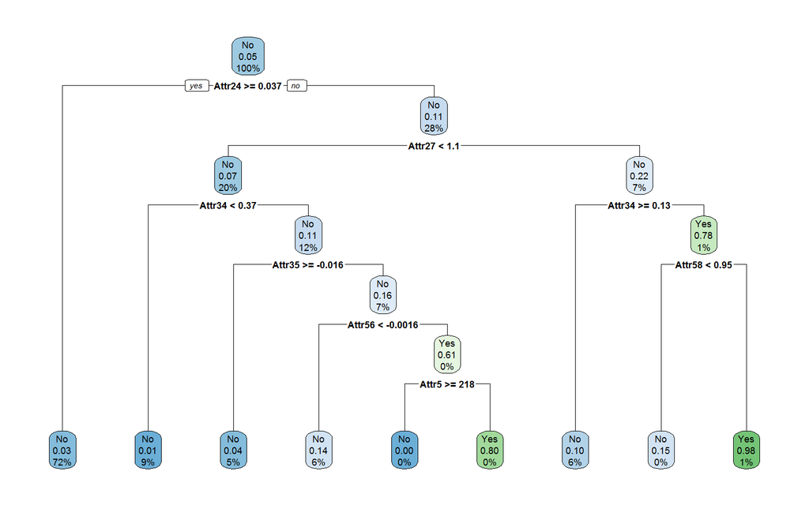

```r
rpart.plot(reg_tree)
```

## Evaluating the model

### Predictions on the test data

- We’ll evaluate the decision tree using the standard error metrics on test data

```r
summary(reg_tree) # detailed summary of splits
```

```
## Call:
## rpart(formula = target ~ ., data = train_data, method = "class")
##   n= 30104
##
##           CP nsplit rel error    xerror       xstd
## 1 0.04889194      0 1.0000000 1.0000000 0.02553787
## 2 0.04318026      3 0.8533242 0.9479095 0.02489680
## 3 0.01010966      4 0.8101439 0.8896504 0.02415524
## 4 0.01000000      8 0.7697053 0.7635367 0.02244912
##
## Variable importance
## Attr34 Attr56 Attr58 Attr27 Attr42 Attr24  Attr9 Attr39 Attr14 Attr18
##     21     11      8      6      6      6      5      4      3      3
##  Attr7 Attr13 Attr12 Attr33 Attr19 Attr41 Attr55  Attr5 Attr35 Attr52
##      3      3      2      2      2      2      2      2      2      1
## Attr22 Attr29 Attr48 Attr49
##      1      1      1      1
##
## Node number 1: 30104 observations,    complexity param=0.04889194
##   predicted class=No   expected loss=0.04846532  P(node) =1
##     class counts: 28645  1459
##    probabilities: 0.952 0.048
##   left son=2 (21824 obs) right son=3 (8280 obs)
##   Primary splits:
##       Attr24 < 0.0365045    to the right, improve=83.19948, (0 missing)
##       Attr35 < -0.03247     to the right, improve=82.47770, (0 missing)
##       Attr39 < -0.018888    to the right, improve=81.90070, (0 missing)
##       Attr26 < 0.0713325    to the right, improve=81.31780, (0 missing)
##       Attr16 < 0.06732      to the right, improve=81.22475, (0 missing)
##   Surrogate splits:
##       Attr14 < 0.00744365   to the right, agree=0.853, adj=0.464, (0 split)
##       Attr18 < 0.00744365   to the right, agree=0.853, adj=0.464, (0 split)
##       Attr7  < 0.00744365   to the right, agree=0.853, adj=0.464, (0 split)
##       Attr12 < 0.02583      to the right, agree=0.852, adj=0.463, (0 split)
##       Attr19 < 0.0045421    to the right, agree=0.847, adj=0.444, (0 split)
##
## Node number 2: 21824 observations
##   predicted class=No   expected loss=0.02556818  P(node) =0.7249535
##     class counts: 21266   558
##    probabilities: 0.974 0.026
```

[output cut: 151 more lines]

```
##       Attr24 < 0.00280055   to the right, agree=0.803, adj=0.167, (0 split)
##       Attr27 < -2518.1      to the left,  agree=0.787, adj=0.100, (0 split)
##       Attr43 < 23.2325      to the left,  agree=0.787, adj=0.100, (0 split)
##       Attr61 < 61.187       to the right, agree=0.787, adj=0.100, (0 split)
##       Attr29 < 4.95835      to the right, agree=0.780, adj=0.067, (0 split)
##
## Node number 110: 30 observations
##   predicted class=No   expected loss=0  P(node) =0.0009965453
##     class counts:    30     0
##    probabilities: 1.000 0.000
##
## Node number 111: 97 observations
##   predicted class=Yes  expected loss=0.1958763  P(node) =0.003222163
##     class counts:    19    78
##    probabilities: 0.196 0.804
```

```r
pred2 = predict(reg_tree, train_data,type = "class")
pred3 = predict(reg_tree, test_data,type = "class")

table(pred2, train_data$target)
```

```
##
## pred2    No   Yes
##   No  28620  1098
##   Yes    25   361
```

```r
table(pred3, test_data$target)
```

```
##
## pred3    No   Yes
##   No  12265   492
##   Yes    11   132
```

# Error metrics for classification can be accessed through the “confusionMatrix()” function from the caret package

```r
conf_train=confusionMatrix(pred2, train_data$target, positive = "No")
conf_test=confusionMatrix(pred3, test_data$target, positive = "No")
conf_train
```

```
## Confusion Matrix and Statistics
##
##           Reference
## Prediction    No   Yes
##        No  28620  1098
##        Yes    25   361
##
##                Accuracy : 0.9627
##                  95% CI : (0.9605, 0.9648)
##     No Information Rate : 0.9515
##     P-Value [Acc > NIR] : < 2.2e-16
##
##                   Kappa : 0.3787
##  Mcnemar's Test P-Value : < 2.2e-16
##
##             Sensitivity : 0.9991
##             Specificity : 0.2474
##          Pos Pred Value : 0.9631
##          Neg Pred Value : 0.9352
##              Prevalence : 0.9515
##          Detection Rate : 0.9507
##    Detection Prevalence : 0.9872
##       Balanced Accuracy : 0.6233
##
##        'Positive' Class : No
##
```

```r
conf_test
```

```
## Confusion Matrix and Statistics
##
##           Reference
## Prediction    No   Yes
##        No  12265   492
##        Yes    11   132
##
##                Accuracy : 0.961
##                  95% CI : (0.9575, 0.9643)
##     No Information Rate : 0.9516
##     P-Value [Acc > NIR] : 1.668e-07
##
##                   Kappa : 0.3322
##  Mcnemar's Test P-Value : < 2.2e-16
##
##             Sensitivity : 0.9991
##             Specificity : 0.2115
##          Pos Pred Value : 0.9614
##          Neg Pred Value : 0.9231
##              Prevalence : 0.9516
##          Detection Rate : 0.9508
##    Detection Prevalence : 0.9889
##       Balanced Accuracy : 0.6053
##
##        'Positive' Class : No
##
```

# Finding the F1 score since it is very important to have high precision and recall for this problem

# Print F1 score

```r
recall_test <- sensitivity(pred3, test_data$target)
precision_test <- posPredValue(pred3, test_data$target)

F1_model_rpart<-F1_score(recall_test,precision_test)

print(F1_model_rpart)
```

```
## [1] 0.9799065
```

# Build KNN model

```r
  # N = 1/3/5/7
  Neigh <-3
  pred=knn(train_data[,num_var], test_data[,num_var],train_data$target , k = Neigh)
  a=table(pred,test_data$target)
```

# Error metrics for classification can be accessed through the “confusionMatrix()” function from the caret package

```r
conf_test=confusionMatrix(pred, test_data$target, positive = "No")
conf_test
```

```
## Confusion Matrix and Statistics
##
##           Reference
## Prediction    No   Yes
##        No  12154   616
##        Yes   122     8
##
##                Accuracy : 0.9428
##                  95% CI : (0.9386, 0.9467)
##     No Information Rate : 0.9516
##     P-Value [Acc > NIR] : 1
##
##                   Kappa : 0.0046
##  Mcnemar's Test P-Value : <2e-16
##
##             Sensitivity : 0.99006
##             Specificity : 0.01282
##          Pos Pred Value : 0.95176
##          Neg Pred Value : 0.06154
##              Prevalence : 0.95163
##          Detection Rate : 0.94217
##    Detection Prevalence : 0.98992
##       Balanced Accuracy : 0.50144
##
##        'Positive' Class : No
##
```

# Finding the F1 score since it is very important to have high precision and recall for this problem

# Print F1 score

```r
recall_test <- sensitivity(pred, test_data$target)
precision_test <- posPredValue(pred, test_data$target)

F1_model_knn<-F1_score(recall_test,precision_test)

print(F1_model_knn)
```

```
## [1] 0.9705342
```

```r
accu= sum(diag(a))/sum(a)
accu
```

```
## [1] 0.9427907
```

# Model Building using Random Forest and tuning

```r
# Build the classification model using randomForest
model = randomForest(target ~ ., data=train_data,
                      keep.forest=TRUE, ntree=50)

# Print and understand the model
print(model)
```

```
##
## Call:
##  randomForest(formula = target ~ ., data = train_data, keep.forest = TRUE,      ntree = 50)
##                Type of random forest: classification
##                      Number of trees: 50
## No. of variables tried at each split: 8
##
##         OOB estimate of  error rate: 3.79%
## Confusion matrix:
##        No Yes class.error
## No  28547  98  0.00342119
## Yes  1042 417  0.71418780
```

```r
# Important attributes
model$importance
```

```
##        MeanDecreaseGini
## Attr1          30.01508
## Attr2          29.52824
## Attr3          35.84599
## Attr4          38.62016
## Attr5          55.02323
## Attr6          50.72044
## Attr7          32.57913
## Attr8          28.35306
## Attr9          58.61952
## Attr10         26.58734
## Attr11         32.78909
## Attr12         25.44439
## Attr13         39.66432
## Attr14         25.21861
## Attr15         41.03721
## Attr16         41.87971
## Attr17         27.09360
## Attr18         30.76686
## Attr19         30.71387
## Attr20         39.44960
## Attr21         33.90015
## Attr22         46.59094
## Attr23         29.86411
## Attr24         76.95382
## Attr25         39.83755
## Attr26         41.60013
## Attr27        188.35105
## Attr28         33.63925
## Attr29         55.55534
## Attr30         35.80251
## Attr31         33.26165
## Attr32         30.49783
## Attr33         30.36793
## Attr34        105.13921
## Attr35         56.57063
## Attr36         42.32140
## Attr37         29.43865
## Attr38         33.81144
## Attr39         49.06891
```

[output cut: 10 more lines]

```
## Attr50         33.02514
## Attr51         34.75531
## Attr52         28.97046
## Attr53         31.52290
## Attr54         36.85272
## Attr55         45.91312
## Attr56         63.23392
## Attr57         31.07678
## Attr58         86.57270
## Attr59         22.80288
## Attr60         43.78370
## Attr61         49.32016
## Attr62         31.55628
## Attr63         28.40989
## Attr64         33.29694
```

```r
round(importance(model), 2)
```

```
##        MeanDecreaseGini
## Attr1             30.02
## Attr2             29.53
## Attr3             35.85
## Attr4             38.62
## Attr5             55.02
## Attr6             50.72
## Attr7             32.58
## Attr8             28.35
## Attr9             58.62
## Attr10            26.59
## Attr11            32.79
## Attr12            25.44
## Attr13            39.66
## Attr14            25.22
## Attr15            41.04
## Attr16            41.88
## Attr17            27.09
## Attr18            30.77
## Attr19            30.71
## Attr20            39.45
## Attr21            33.90
## Attr22            46.59
## Attr23            29.86
## Attr24            76.95
## Attr25            39.84
## Attr26            41.60
## Attr27           188.35
## Attr28            33.64
## Attr29            55.56
## Attr30            35.80
## Attr31            33.26
## Attr32            30.50
## Attr33            30.37
## Attr34           105.14
## Attr35            56.57
## Attr36            42.32
## Attr37            29.44
## Attr38            33.81
## Attr39            49.07
```

[output cut: 10 more lines]

```
## Attr50            33.03
## Attr51            34.76
## Attr52            28.97
## Attr53            31.52
## Attr54            36.85
## Attr55            45.91
## Attr56            63.23
## Attr57            31.08
## Attr58            86.57
## Attr59            22.80
## Attr60            43.78
## Attr61            49.32
## Attr62            31.56
## Attr63            28.41
## Attr64            33.30
```

```r
# Extract and store important variables obtained from the random forest model
rf_Imp_Attr = data.frame(model$importance)
rf_Imp_Attr = data.frame(row.names(rf_Imp_Attr),rf_Imp_Attr[,1])
colnames(rf_Imp_Attr) = c('Attributes', 'Importance')
rf_Imp_Attr = rf_Imp_Attr[order(rf_Imp_Attr$Importance, decreasing = TRUE),]
rf_Imp_Attr
```

```
##    Attributes Importance
## 27     Attr27  188.35105
## 34     Attr34  105.13921
## 46     Attr46   98.94766
## 58     Attr58   86.57270
## 24     Attr24   76.95382
## 56     Attr56   63.23392
## 9       Attr9   58.61952
## 35     Attr35   56.57063
## 29     Attr29   55.55534
## 5       Attr5   55.02323
## 40     Attr40   50.87377
## 6       Attr6   50.72044
## 61     Attr61   49.32016
## 39     Attr39   49.06891
```

[output cut: 50 more lines]

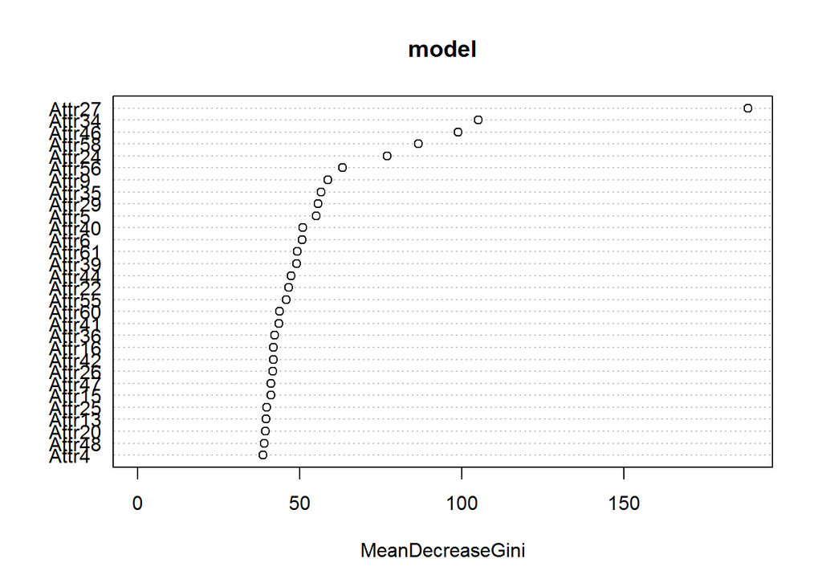

```r
# plot (directly prints the important attributes)
varImpPlot(model)
```

```r
# Predict on Train data
pred_Train_rd = predict(model,
                     train_data[,setdiff(names(train_data), "target")],
                     type="response",
                     norm.votes=TRUE)

# Build confusion matrix and find accuracy
cm_Train = table("actual"= train_data$target, "predicted" = pred_Train_rd);
accu_Train= sum(diag(cm_Train))/sum(cm_Train)
rm(pred_Train, cm_Train)
# Predicton Test Data
pred_Test_rd = predict(model, test_data[,setdiff(names(test_data),
                                              "target")],
                    type="response",
                    norm.votes=TRUE)

# Build confusion matrix and find accuracy
cm_Test = table("actual"=test_data$target, "predicted"=pred_Test_rd);
accu_Test= sum(diag(cm_Test))/sum(cm_Test)
rm(pred_Test, cm_Test)
accu_Train
```

```
## [1] 0.9998007
```

```r
accu_Test
```

```
## [1] 0.9611628
```

```r
# Build randorm forest using top 9 important attributes.
top_Imp_Attr = as.character(rf_Imp_Attr$Attributes[1:9])

# Build the classification model using randomForest
model_Imp = randomForest(target~.,
                         data=train_data[,c(top_Imp_Attr,"target")],
                         keep.forest=TRUE,ntree=50)

# Print and understand the model
print(model_Imp)
```

```
##
## Call:
##  randomForest(formula = target ~ ., data = train_data[, c(top_Imp_Attr,      "target")], keep.forest = TRUE, ntree = 50)
##                Type of random forest: classification
##                      Number of trees: 50
## No. of variables tried at each split: 3
##
##         OOB estimate of  error rate: 3.35%
## Confusion matrix:
##        No Yes class.error
## No  28562  83 0.002897539
## Yes   925 534 0.633995888
```

```r
# Important attributes
model_Imp$importanced
```

[output not shown]

```r
# Predict on Train data
pred_Train_rd_attr = predict(model_Imp, train_data[,top_Imp_Attr],
                     type="response", norm.votes=TRUE)


# Build confusion matrix and find accuracy
cm_Train = table("actual" = train_data$target,
                 "predicted" = pred_Train_rd_attr);
accu_Train_Imp = sum(diag(cm_Train))/sum(cm_Train)
rm(pred_Train, cm_Train)
# Predicton Test Data
pred_Test_rd_attr = predict(model_Imp, test_data[,top_Imp_Attr],
                    type="response", norm.votes=TRUE)

# Build confusion matrix and find accuracy
cm_Test = table("actual" = test_data$target,
                "predicted" = pred_Test_rd_attr);
accu_Test_Imp = sum(diag(cm_Test))/sum(cm_Test)
rm(pred_Test, cm_Test)
accu_Train
```

```
## [1] 0.9998007
```

```r
accu_Test
```

```
## [1] 0.9611628
```

```r
accu_Train_Imp
```

```
## [1] 0.999701
```

```r
accu_Test_Imp
```

```
## [1] 0.9648062
```

```r
top_Imp_Attr = as.character(rf_Imp_Attr$Attributes[1:9])
set.seed(123)
x <- train_data[,!(names(train_data) %in% c("target"))]
y <- train_data[,(names(train_data) %in% c("target"))]
str(y)
```

```
##  Factor w/ 2 levels "No","Yes": 1 1 1 1 1 1 1 1 1 1 ...
```

```
## mtry = 8  OOB error = 3.89%
## Searching left ...
## mtry = 4     OOB error = 4.51%
## -0.1615385 0.05
## Searching right ...
## mtry = 16    OOB error = 3.17%
## 0.1837607 0.05
## mtry = 32    OOB error = 3.01%
## 0.05026178 0.05
## mtry = 64    OOB error = 2.92%
## 0.030871 0.05
```

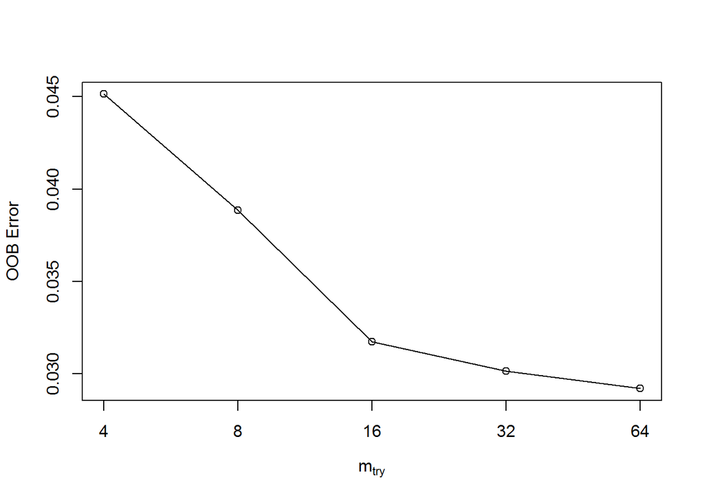

```r
tunedmodel <-tuneRF(x,y,ntreeTry = 50,trace=TRUE,plot=TRUE,doBest = TRUE)
```

```r
print(tunedmodel)
```

```
##
## Call:
##  randomForest(x = x, y = y, mtry = res[which.min(res[, 2]), 1])
##                Type of random forest: classification
##                      Number of trees: 500
## No. of variables tried at each split: 64
##
##         OOB estimate of  error rate: 2.92%
## Confusion matrix:
##        No Yes class.error
## No  28559  86 0.003002269
## Yes   794 665 0.544208362
```

```r
tunedmodel$importance
```

```
##        MeanDecreaseGini
## Attr1         13.953400
## Attr2         10.005125
## Attr3         22.457288
## Attr4         41.884584
## Attr5        116.765612
## Attr6         72.676802
## Attr7          9.065630
## Attr8         10.432779
## Attr9         28.616017
## Attr10        10.660590
## Attr11        16.801657
## Attr12        19.031605
## Attr13        26.037724
## Attr14         8.567603
## Attr15        37.310891
## Attr16        23.017576
## Attr17        10.054207
## Attr18         8.860947
## Attr19        19.963744
## Attr20        28.337957
## Attr21        37.989372
## Attr22        27.856060
## Attr23        15.668353
## Attr24        91.835557
## Attr25        33.539141
## Attr26        29.817902
## Attr27       171.614384
## Attr28        18.718942
## Attr29        42.836262
## Attr30        29.863328
## Attr31        13.851694
## Attr32        16.712308
## Attr33        19.308324
## Attr34       414.786772
## Attr35        55.309380
## Attr36        32.719865
## Attr37        36.645510
## Attr38        21.248156
## Attr39        55.120814
```

[output cut: 10 more lines]

```
## Attr50        30.235981
## Attr51        18.394851
## Attr52        12.860534
## Attr53        17.339558
## Attr54        21.765301
## Attr55        44.597316
## Attr56       131.563659
## Attr57        33.819953
## Attr58       148.218212
## Attr59        21.871314
## Attr60        30.612569
## Attr61        51.510010
## Attr62        14.208051
## Attr63        14.986133
## Attr64        24.531488
```

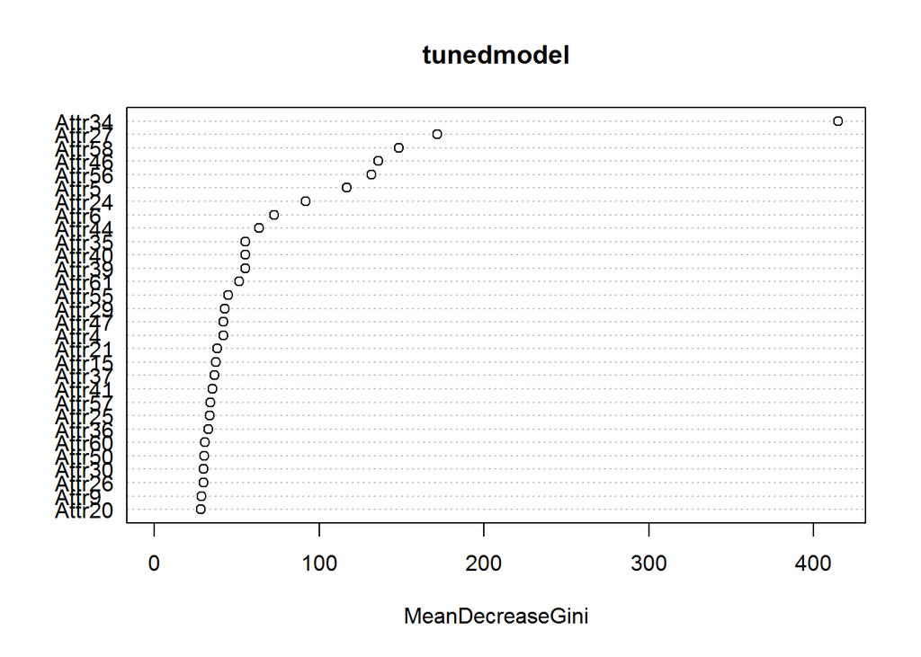

```r
varImpPlot(tunedmodel)
```

```r
# Predict on Train data
pred_Train_rd_tune = predict(tunedmodel, train_data,
                     type="response", norm.votes=TRUE)

# Build confusion matrix and find accuracy
cm_Train = table("actual" = train_data$target,
                 "predicted" = pred_Train_rd_tune);
accu_Train = sum(diag(cm_Train))/sum(cm_Train)
rm(pred_Train, cm_Train)
# Predicton Test Data
pred_Test_rd_tune = predict(tunedmodel, test_data,
                    type="response", norm.votes=TRUE)

# Build confusion matrix and find accuracy
cm_Test = table("actual" = test_data$target,
                "predicted" = pred_Test_rd_tune);
accu_Test = sum(diag(cm_Test))/sum(cm_Test)
rm(pred_Test, cm_Test)
accu_Train
```

```
## [1] 1
```

```r
accu_Test
```

```
## [1] 0.9692248
```

# Error metrics for classification can be accessed through the “confusionMatrix()” function from the caret package

```r
conf_train_rd=confusionMatrix(pred_Train_rd, train_data$target, positive = "No")
conf_test_rd=confusionMatrix(pred_Test_rd, test_data$target, positive = "No")

conf_train_rd_attr=confusionMatrix(pred_Train_rd_attr, train_data$target, positive = "No")
conf_test_rd_attr=confusionMatrix(pred_Test_rd_attr, test_data$target, positive = "No")

conf_train_rd_tune=confusionMatrix(pred_Train_rd_tune, train_data$target, positive = "No")
conf_test_rd_tune=confusionMatrix(pred_Test_rd_tune, test_data$target, positive = "No")

conf_train_rd
```

```
## Confusion Matrix and Statistics
##
##           Reference
## Prediction    No   Yes
##        No  28645     6
##        Yes     0  1453
##
##                Accuracy : 0.9998
##                  95% CI : (0.9996, 0.9999)
##     No Information Rate : 0.9515
##     P-Value [Acc > NIR] : < 2e-16
##
##                   Kappa : 0.9978
##  Mcnemar's Test P-Value : 0.04123
##
##             Sensitivity : 1.0000
##             Specificity : 0.9959
##          Pos Pred Value : 0.9998
##          Neg Pred Value : 1.0000
##              Prevalence : 0.9515
##          Detection Rate : 0.9515
##    Detection Prevalence : 0.9517
##       Balanced Accuracy : 0.9979
##
##        'Positive' Class : No
##
```

```r
conf_test_rd
```

```
## Confusion Matrix and Statistics
##
##           Reference
## Prediction    No   Yes
##        No  12243   468
##        Yes    33   156
##
##                Accuracy : 0.9612
##                  95% CI : (0.9577, 0.9644)
##     No Information Rate : 0.9516
##     P-Value [Acc > NIR] : 1.044e-07
##
##                   Kappa : 0.3696
##  Mcnemar's Test P-Value : < 2.2e-16
##
##             Sensitivity : 0.9973
##             Specificity : 0.2500
##          Pos Pred Value : 0.9632
##          Neg Pred Value : 0.8254
##              Prevalence : 0.9516
##          Detection Rate : 0.9491
##    Detection Prevalence : 0.9853
##       Balanced Accuracy : 0.6237
##
##        'Positive' Class : No
##
```

```r
conf_train_rd_attr
```

```
## Confusion Matrix and Statistics
##
##           Reference
## Prediction    No   Yes
##        No  28644     8
##        Yes     1  1451
##
##                Accuracy : 0.9997
##                  95% CI : (0.9994, 0.9999)
##     No Information Rate : 0.9515
##     P-Value [Acc > NIR] : <2e-16
##
##                   Kappa : 0.9968
##  Mcnemar's Test P-Value : 0.0455
##
##             Sensitivity : 1.0000
##             Specificity : 0.9945
##          Pos Pred Value : 0.9997
##          Neg Pred Value : 0.9993
##              Prevalence : 0.9515
##          Detection Rate : 0.9515
##    Detection Prevalence : 0.9518
##       Balanced Accuracy : 0.9972
##
##        'Positive' Class : No
##
```

```r
conf_test_rd_attr
```

```
## Confusion Matrix and Statistics
##
##           Reference
## Prediction    No   Yes
##        No  12249   427
##        Yes    27   197
##
##                Accuracy : 0.9648
##                  95% CI : (0.9615, 0.9679)
##     No Information Rate : 0.9516
##     P-Value [Acc > NIR] : 1.565e-13
##
##                   Kappa : 0.4506
##  Mcnemar's Test P-Value : < 2.2e-16
##
##             Sensitivity : 0.9978
##             Specificity : 0.3157
##          Pos Pred Value : 0.9663
##          Neg Pred Value : 0.8795
##              Prevalence : 0.9516
##          Detection Rate : 0.9495
##    Detection Prevalence : 0.9826
##       Balanced Accuracy : 0.6568
##
##        'Positive' Class : No
##
```

```r
conf_train_rd_tune
```

```
## Confusion Matrix and Statistics
##
##           Reference
## Prediction    No   Yes
##        No  28645     0
##        Yes     0  1459
##
##                Accuracy : 1
##                  95% CI : (0.9999, 1)
##     No Information Rate : 0.9515
##     P-Value [Acc > NIR] : < 2.2e-16
##
##                   Kappa : 1
##  Mcnemar's Test P-Value : NA
##
##             Sensitivity : 1.0000
##             Specificity : 1.0000
##          Pos Pred Value : 1.0000
##          Neg Pred Value : 1.0000
##              Prevalence : 0.9515
##          Detection Rate : 0.9515
##    Detection Prevalence : 0.9515
##       Balanced Accuracy : 1.0000
##
##        'Positive' Class : No
##
```

```r
conf_test_rd_tune
```

```
## Confusion Matrix and Statistics
##
##           Reference
## Prediction    No   Yes
##        No  12245   366
##        Yes    31   258
##
##                Accuracy : 0.9692
##                  95% CI : (0.9661, 0.9721)
##     No Information Rate : 0.9516
##     P-Value [Acc > NIR] : < 2.2e-16
##
##                   Kappa : 0.5514
##  Mcnemar's Test P-Value : < 2.2e-16
##
##             Sensitivity : 0.9975
##             Specificity : 0.4135
##          Pos Pred Value : 0.9710
##          Neg Pred Value : 0.8927
##              Prevalence : 0.9516
##          Detection Rate : 0.9492
##    Detection Prevalence : 0.9776
##       Balanced Accuracy : 0.7055
##
##        'Positive' Class : No
##
```

# Finding the F1 score since it is very important to have high precision and recall for this problem

# Print F1 score

```r
recall_test_rd <- sensitivity(pred_Test_rd, test_data$target)
precision_test_rd <- posPredValue(pred_Test_rd, test_data$target)

recall_test_rd_attr <- sensitivity(pred_Test_rd_attr, test_data$target)
precision_test_rd_attr <- posPredValue(pred_Test_rd_attr, test_data$target)

recall_test_rd_tune <- sensitivity(pred_Test_rd_tune, test_data$target)
precision_test_rd_tune <- posPredValue(pred_Test_rd_tune, test_data$target)

F1_model_rpart_rd<-F1_score(recall_test_rd,precision_test_rd)
F1_model_rpart_rd_attr<-F1_score(recall_test_rd_attr,precision_test_rd_attr)
F1_model_rpart_rd_tune<-F1_score(recall_test_rd_tune,precision_test_rd_tune)

print(F1_model_rpart_rd)
```

```
## [1] 0.9799496
```

```r
print(F1_model_rpart_rd_attr)
```

```
## [1] 0.9818051
```

```r
print(F1_model_rpart_rd_tune)
```

```
## [1] 0.9840479
```